# Michael Hornsby EDRM 878 Assignment 5

Problem 9.7

Import data:

```r
data(shuttles)

summary(shuttles)
```

```
      Temp          Damaged
 Min.   :53.00   Min.   :0.0000
 1st Qu.:67.00   1st Qu.:0.0000
 Median :70.00   Median :0.0000
 Mean   :69.57   Mean   :0.3913
 3rd Qu.:75.00   3rd Qu.:1.0000
 Max.   :81.00   Max.   :2.0000
```

Plot of the data:

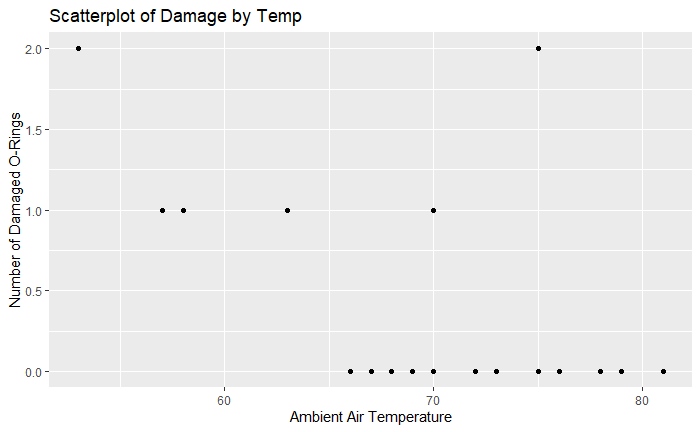

```r
shuttles %>%
  ggplot(aes(x = Temp, y = Damaged)) +
  geom_point() +
  labs(title = "Scatterplot of Damage by Temp",
       x = "Ambient Air Temperature",
       y = "Number of Damaged O-Rings")
```

create proportion:

```r
shuttles$PropDamaged <- shuttles$Damaged/6
```

Fit the proposed model:

```r
glm.out = glm(PropDamaged ~ Temp,
              family=binomial(logit),
              data = shuttles)
```

```
non-integer #successes in a binomial glm!
```

```r
summary(glm.out)
```

```
Call:
glm(formula = PropDamaged ~ Temp, family = binomial(logit), data = shuttles)

Deviance Residuals:
     Min        1Q    Median        3Q       Max
-0.38876  -0.31965  -0.22093  -0.01788   1.08248

Coefficients:
            Estimate Std. Error z value Pr(>|z|)
(Intercept)   5.0850     7.4770   0.680    0.496
Temp         -0.1156     0.1152  -1.004    0.316

(Dispersion parameter for binomial family taken to be 1)

    Null deviance: 4.0384  on 22  degrees of freedom
Residual deviance: 3.0144  on 21  degrees of freedom
AIC: 7.2026

Number of Fisher Scoring iterations: 6
```

I wouldn’t say this model looks good, which is expected given the plot above. The p-values are not significant at any reasonable alpha level.

Diagnostic Analysis:

```r
c(df.residual(glm.out),
  deviance(glm.out),
  sum(resid(glm.out, type = "pearson")^2))
```

```
[1] 21.000000  3.014388  4.996716
```

Interesting, I believe this suggests underdispersion? Our residual deviance is much less than our residual df.

```r
influence.measures(glm.out)
```

```
Influence measures of
     glm(formula = PropDamaged ~ Temp, family = binomial(logit), data = shuttles) :
```

|  | dfb.1_ | dfb.Temp | dffit | cov.r | cook.d | hat | inf |
| --- | --- | --- | --- | --- | --- | --- | --- |
| 1 | 0.501312018 | -0.468628629 | 0.560984274 | 2.060059 | 2.458547e-02 | 0.48244190 | * |
| 2 | -0.048456516 | 0.043626811 | -0.062014031 | 1.416438 | 2.832274e-04 | 0.22268284 | * |
| 3 | 0.003824946 | -0.003388339 | 0.005205541 | 1.346084 | 2.046828e-06 | 0.18096735 | * |
| 4 | 0.046338732 | -0.029157418 | 0.152250574 | 1.150879 | 2.023169e-03 | 0.07060950 |  |
| 5 | 0.020764104 | -0.049652091 | -0.250463255 | 1.044307 | 2.325318e-03 | 0.05311926 |  |
| 6 | 0.047512836 | -0.073577810 | -0.231809982 | 1.054913 | 1.995728e-03 | 0.05136675 |  |
| 7 | 0.047512836 | -0.073577810 | -0.231809982 | 1.054913 | 1.995728e-03 | 0.05136675 |  |
| 8 | 0.047512836 | -0.073577810 | -0.231809982 | 1.054913 | 1.995728e-03 | 0.05136675 |  |
| 9 | 0.068484305 | -0.092015766 | -0.217396834 | 1.065507 | 1.758164e-03 | 0.05085287 |  |
| 10 | 0.084605017 | -0.105854251 | -0.205836738 | 1.075891 | 1.578394e-03 | 0.05120944 |  |

[output cut: 13 more lines]

These influential points (1, 2, 3, and 18) are about what I expected. However, I certainly wouldn’t throw them out. I think it is the nature of this data for these points to be influential given the number of points we do have and that only 2 observations had 2 O-rings fail.

Ulimately, I wouldn’t say these diagnostics look ‘good’, but given this situation is a ‘looking back’ situation, I wouldn’t say it is wise to throw any observations out. I think the best solution is to look for additional variables to help explain things and try and address the underdispersion?

Predicted probability of an O-ring failure for 31 degrees:

```r
estuff <- exp(5.085 - (0.1156*31))
estuff/(1+estuff)
```

```
[1] 0.8177832
```

The predicted probability of an O-ring failure at 31 degrees F is 81.77832%.

The ED50 in this context would tell us at what ambient air temperature we would expect 50% of O-rings to fail. I believe a more sensible and useful ED would be 16.67 maybe? This keeps the expected number of O-rings to fail for each launch at 1, which is too many given the situation. Realistically, I would probably picked an ED between 5 and 15 to be on the safe side.

Problem 10.12

```r
data(dwomen)

dwomen$Depression <- as.factor(dwomen$Depression)
dwomen$SLE <- as.factor(dwomen$SLE)
dwomen$Children <- as.factor(dwomen$Children)

summary(dwomen)
```

```
     Counts       Depression  SLE    Children
 Min.   :  0.00   No :4      No :4   No :4
 1st Qu.:  7.75   Yes:4      Yes:4   Yes:4
 Median : 16.00
 Mean   : 52.38
 3rd Qu.: 47.75
 Max.   :231.00
```

```r
my.model <- glm(Counts ~ (SLE + Children) * Depression,
              family = poisson,
              data = dwomen)

anova(my.model, test = "Chisq")
```

```
Analysis of Deviance Table

Model: poisson, link: log

Response: Counts

Terms added sequentially (first to last)

                    Df Deviance Resid. Df Resid. Dev  Pr(>Chi)
NULL                                    7     717.32
SLE                  1    19.92         6     697.40 8.066e-06 ***
Children             1   312.41         5     384.98 < 2.2e-16 ***
Depression           1   330.63         4      54.35 < 2.2e-16 ***
SLE:Depression       1    44.36         3       9.99 2.725e-11 ***
Children:Depression  1     7.45         2       2.54  0.006353 **
---
Signif. codes:  0 ‘***’ 0.001 ‘**’ 0.01 ‘*’ 0.05 ‘.’ 0.1 ‘ ’ 1
```

From this model we can see a few things. All three main effects predict significantly different count responses. Additionally, there are interaction effects between the SLE and Depression variables and the Children and Depression variables. From this we know that our main effects are certainly not all independent. Given that we have a cell with a 0 count, I’m very hesistant to draw any substantial conclusions from this model and I would say further data might be necessary for any realistic conclusions.